# SING Bioinformatics Workshop - Part 2

Authors

Affiliation

Murray Cadzow

University of Otago

Pascale Lubbe

University of Otago

## Population stratification by PCA’s (15mins)

We might want to visualize what variation looks like in different populations across the entire genome. We can do this with a technique called a Principal Components Analysis (PCA). Principal component analysis is a statistical dimension reduction technique that transforms potentially correlated variables into a linear and non-correlated set of variables. In a genetic context PCA is used to reduce variation at many thousands of markers into a handful of components that represent the majority of the variation of the data. The components are ordered such that the first principal component (PC) captures the most variation, with each subsequent component capturing less. These components often, but not necessarily, represent population differences and population substructure.

**Generating PCA Data**

```bash
for CHR in $(seq 1 22)
do
  wget http://ftp.1000genomes.ebi.ac.uk/vol1/ftp/release/20130502/ALL.chr${CHR}.phase3_callmom-v0_4.20130502.genotypes.vcf.gz
  wget http://ftp.1000genomes.ebi.ac.uk/vol1/ftp/release/20130502/ALL.chr${CHR}.phase3_callmom-v0_4.20130502.genotypes.vcf.gz.tbi
  bcftools view -m 2 -M 2 -v snps -O z -o ALL_chr${CHR}.no_indel.biallelic.vcf.gz ALL.chr${CHR}.phase3_callmom-v0_4.20130502.genotypes.vcf.gz
  # clean up
  rm ALL.chr${CHR}.phase3_callmom-v0_4.20130502.genotypes.vcf.gz
  rm ALL.chr${CHR}.phase3_callmom-v0_4.20130502.genotypes.vcf.gz.tbi
done

# combine all chromosomes together
bcftools concat \
  -O z \
  -o 1KGP_allchr.vcf.gz \
  ALL_chr1.no_indel.biallelic.vcf.gz \
  ALL_chr2.no_indel.biallelic.vcf.gz \
  ALL_chr3.no_indel.biallelic.vcf.gz \
  ALL_chr4.no_indel.biallelic.vcf.gz \
  ALL_chr5.no_indel.biallelic.vcf.gz \
  ALL_chr6.no_indel.biallelic.vcf.gz \
  ALL_chr7.no_indel.biallelic.vcf.gz \
  ALL_chr8.no_indel.biallelic.vcf.gz \
  ALL_chr9.no_indel.biallelic.vcf.gz \
  ALL_chr10.no_indel.biallelic.vcf.gz \
  ALL_chr11.no_indel.biallelic.vcf.gz \
  ALL_chr12.no_indel.biallelic.vcf.gz \
  ALL_chr13.no_indel.biallelic.vcf.gz \
  ALL_chr14.no_indel.biallelic.vcf.gz \
  ALL_chr15.no_indel.biallelic.vcf.gz \
  ALL_chr16.no_indel.biallelic.vcf.gz \
  ALL_chr17.no_indel.biallelic.vcf.gz \
  ALL_chr18.no_indel.biallelic.vcf.gz \
  ALL_chr19.no_indel.biallelic.vcf.gz \
  ALL_chr20.no_indel.biallelic.vcf.gz \
  ALL_chr21.no_indel.biallelic.vcf.gz \
  ALL_chr22.no_indel.biallelic.vcf.gz

# find independent SNPs
plink \
  --vcf 1KGP_allchr.vcf.gz \
  --maf 0.1 \
  --indep-pairwise 50 5 0.2 \
  --out 1KGP_allchr

# create an empty affection file that is required for
# Plink to use the --make-pheno
# which in turn is required for the creation of the
# ped file just the way SmartPCA wants it
touch cases.txt
plink \
  --vcf 1KGP_allchr.vcf.gz \
  --extract 1KGP_allchr.prune.in \
  --recode \
  --out 1KGP_allchr_indep \
  --make-pheno cases.txt '*'
```

Contents of `_1KGP_allchr_indep_eigen.pca.par_`:

```
genotypename: 1KGP_allchr_indep.eigenstratgeno
snpname: 1KGP_allchr_indep.snp
indivname: 1KGP_allchr_indep.ind
evecoutname: 1KGP_allchr_indep_eigen.pca.evec
evaloutname: 1KGP_allchr_indep_eigen.eval
altnormstyle: NO
numoutevec: 10
numoutlieriter: 0
numoutlierevec: 10
outliersigmathresh: 6
qtmode: 0
snpweightoutname: example.snpwt
```

```bash
# calculate the principle components
smartpca -p 1KGP_allchr_indep_eigen.pca.par > smartpca.log

tr -s ' ' < 1KGP_allchr_indep_eigen.pca.evec | sed 's/^ //g' | tr ' ' '\t' > 1kgp_allchr.indep_snp.pca.evec.tsv
```

The above code created the file `1kgp_allchr.indep_snp.pca.evec.tsv` which contains the PCA data we will use now.

For this section ensure you are using the R Console tab so that we can use the R programming language for some data exploration.

[figure not shown]

We’re going to have a look at the PCA plot of the 1000 Genomes data. The following code in `Console` will generate the plot.

```r
library(tidyverse)
```

```r
pca_data <- read_delim("pca/1kgp_allchr.indep_snp.pca.evec.tsv",
  col_names = c("sample", paste0("PC",1:10),"case_control"),
  comment = "#",
  col_select = -"case_control") %>%
  left_join(read_delim("vcf/1kgp-phase3-samples.txt",
    col_names = TRUE,
    col_select = c("sample", "pop","super_pop")),
    by = "sample")

pc_loadings <- read_delim("pca/1kgp_allchr.indep_snp.pca.evec.tsv",
  col_names = FALSE,
  n_max = 1)
```

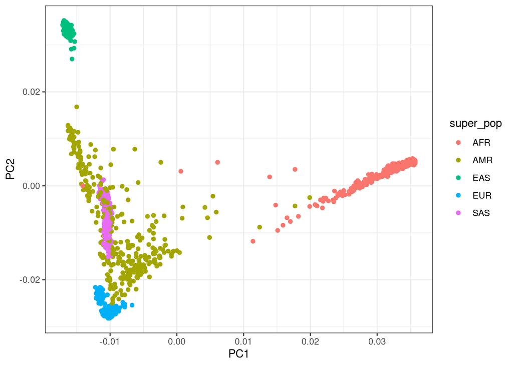

```r
theme_set(theme_bw())

ggplot(data = pca_data, aes(x = PC1, y = PC2, colour = super_pop)) + geom_point()
```

The data are color coded into five “super-populations”: African, Admixed American, European, East Asian, and South Asian.

### Exercise

Investigate different PCs to see which combinations are best to visualise separation between different populations.

```r
# Use this template code
ggplot(data = pca_data,
       aes(x = PC1, # change the number (1-10)
           y = PC2, # change the number (1-10)
           colour = super_pop)) + geom_point()
```

1. How does changing the PC axes change the shape of the data?
2. Which axes explain most of the differences between populations?

## Mitochondrial Haplotypes (15 min)

Mitochondria contain their own short, circular DNA sequences that are distinct from the rest of the genome. They are present in large copy number, mutate relatively rapidly, and their small size and distinctiveness makes them easy to target and sequence, especially in large, mixed samples such as at the population level.

Mitochondrial DNA is inherited maternally and does not undergo recombination on the way. These characteristics make them particularly suitable for Haplotype analysis. Haplotypes are blocks of SNPs that get inherited together, and which are eventually broken up by recombination, the ‘mixing’ of maternal and paternal DNA that occurs during the formation of eggs and sperm. The stability of mitochondrial haplotypes makes them useful for tracking long term evolutionary patterns, such as population stratification.

As populations become separated and accumulate mutations, haplotypes unique to those populations are formed. Haplotype analysis aims to reconstruct the relationships between haplotypes, and family trees (phylogenies) can be reconstructed that trace their evolution. We will be using 1000 Genomes data to explore human haplotype variation across the globe.

### Haplogroup Exercise

In the lower right-hand side of R Studio, in the Files tab, find the file

`vcf/1kgp.chrMT.vcf.gz`

and select by clicking the checkbox. Then click on the settings gear to open a drop-down menu and select `Export` to save it to your computer locally.

In the web browser, navigate to https://haplogrep.i-med.ac.at/ and upload the file using the `Browse...` button. Choose the following options:

File Format: VCF  
Phylogenetic tree: PhyloTree 17.0  
Distance Function: Kulczynski  
Output: (leave blank)

Then select **Upload and Classify**

The program may take a few minutes to run before it opens your results in a new menu. These results will show you the haplotype clusters found in the file, and some quality control metrics.

1. Click on a haplotype cluster to open a new window, which will describe the prevalence of that cluster in different global populations. Haplogrep will also display a phylogenetic tree that describes the relationships of haplogroups in the cluster.
2. Navigate to the Samples table at the top of the page. Here, you can click on any variant in the Mutations column to explore metrics specific to that variant, such as its frequency in different populations.
3. Continue to explore the outputs of Haplogrep for this global sample of individuals.

### Haplotype tree exercise (10min)

We’ll now return to the data file we created earlier in the day. Run the following code in the R `Console` to create a dendrogram, a tree that groups samples by their similarity.

```r
library(fastreeR)
```

```r
myVcfDist <- fastreeR::vcf2dist(inputFile = "vcf/pop.chrMT.vcf.gz", threads = 1)
```

```r
myVcfTreeStats <- stats::hclust(myVcfDist)
```

```r
plot(myVcfTreeStats, ann = FALSE, cex = 0.5)
```

[output not shown]

1. How much variation is present in your population?
2. How many major groups are present?
3. Looking at the vertical axis, how much variation is actually present in the group? How different is this to other groups?

# Appendix

## R quick reference

RStudio’s GUI is generally easy to navigate:

- In the lower right, the ‘files’ tab will display the directories and files for the workshop
- In the lower right, the ‘Plots’ tab will show you the last plot you created
- On the lower left, you can switch between the `Terminal` tab for BASH and `Console` for R code

If you want to learn more R take a look through https://datacarpentry.org/R-ecology-lesson/